# Lecture 01

February 15, 2016

## Population and Samples

When it is not feasible to collect data for every case in the population, we often use **sampling**:

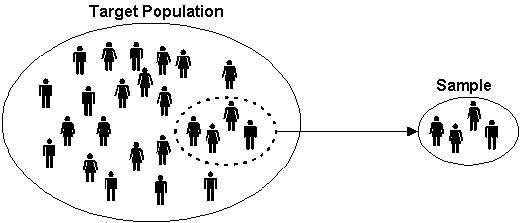

If the sample is **representative** of the population, then the results of the sample are **generalizable**.

## Population and Samples

How do we take a representative (AKA unbiased) sample?

By sampling **randomly**, i.e. each individual has equal probability of being sampled.

## Sample vs Population Values

| Value | Population Parameter | Sample Value |
| --- | --- | --- |
| Mean | \(\mu\) | \(\overline{x}\) |
| Variance | \(\sigma^2\) | \(s^2\) |
| Standard Deviation | \(\sigma\) | \(s\) |
| Proportion | \(p\) | \(\widehat{p}\) |

## Histogram

Consider the `FlightDelays` dataset (LGA). We consider the flight `Delays` of the 1123 United Airlines flights:

```
## Source: local data frame [9 x 2]
##
##   time_interval num_flights
##          (fctr)       (int)
## 1       [-50,0]         722
## 2        (0,50]         249
## 3      (50,100]          86
## 4     (100,150]          39
## 5     (150,200]          14
## 6     (200,250]           7
## 7     (250,300]           3
## 8     (300,350]           2
## 9     (350,400]           1
```

## (Frequency) Histogram

In this case the height of the bars reflect the count/frequency.

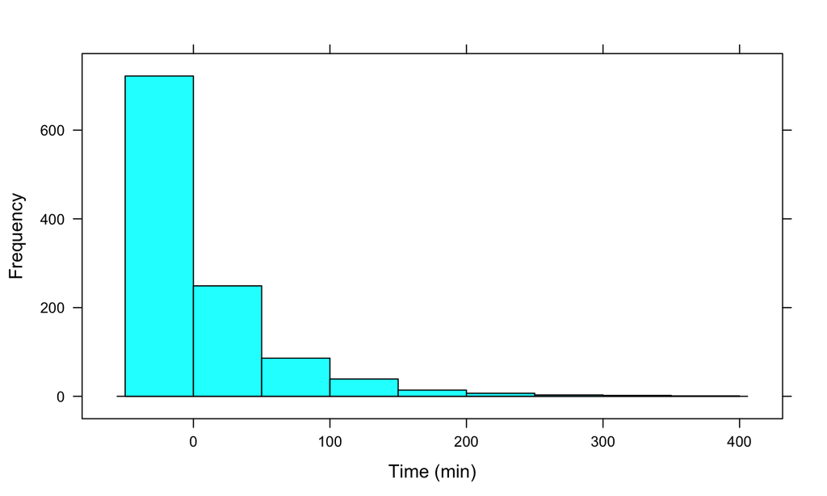

## (Density) Histogram

In this case the height of the bars reflect the density so that the sum of the areas of the boxes is 1.

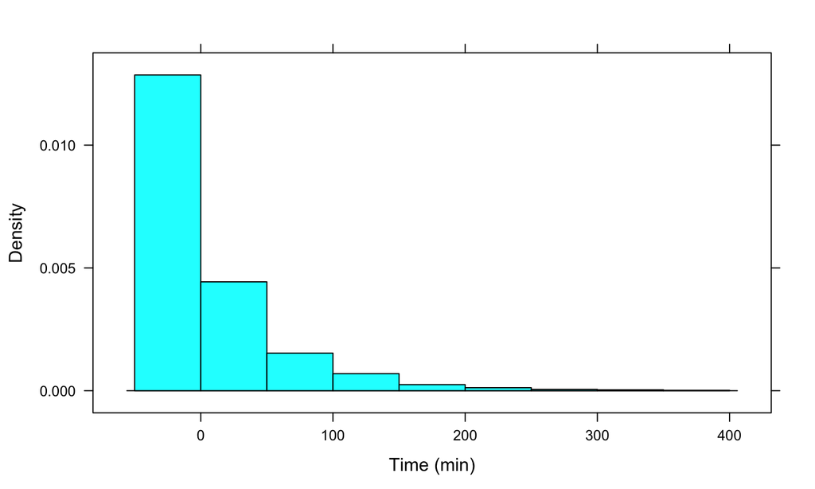

## Histogram as a Visual Approximation

Say you take a sample of \(n=1000\) values from a Normal\((0,1)\) random variable with pdf \(f(z) = \frac{1}{\sqrt{2\pi}}\exp\left(-\frac{1}{2}z^2\right)\)

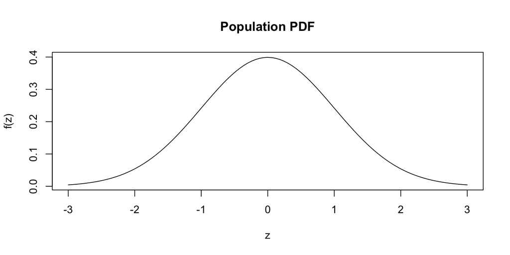

## Histogram as a Visual Approximation

The histogram is visual approximation of the pdf \(f(z)\).

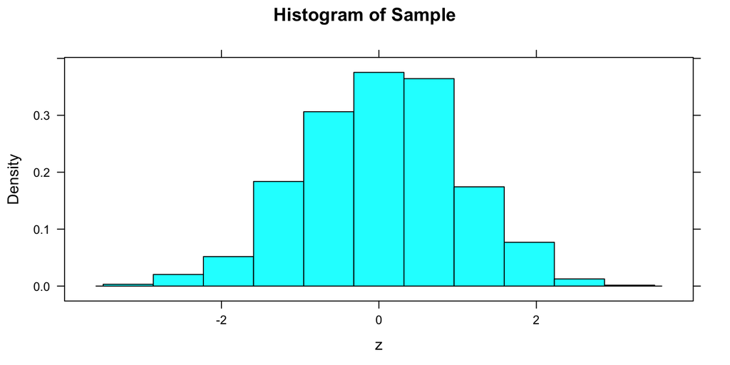

## Mean vs Median

Say at company \(X\), there 5 employees with the following weekly income:

| Salary | CEO | Grunt 1 | Grunt 2 | Grunt 3 | Grunt 4 |
| --- | --- | --- | --- | --- | --- |
| $ | 1000 | 20 | 21 | 30 | 40 |

Then:

- Mean $222.2
- Median $30

## Boxplots

United Flight Delays from LGA

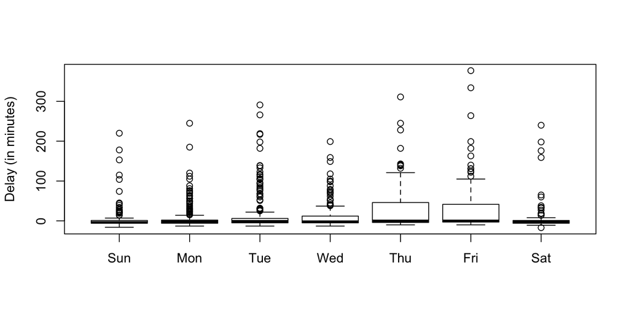

## Boxplots

United Flight Delays from LGA

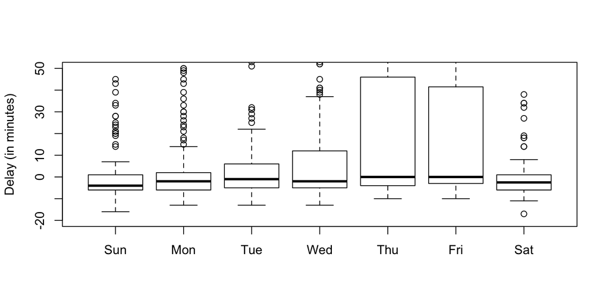

## Boxplots without the Whiskers

What is [middle class](https://www.washingtonpost.com/news/wonk/wp/2015/03/23/middle-class-varies-from-30000-in-detroit-to-100000-in-san-francisco/) in various cities?

## Percentiles

[Growth Charts](http://www.chartsgraphsdiagrams.com/HealthCharts/growth-2-20-girls.html)